# Methods for Automating Job Submission

2022-04-15

## Outline

- Example workflow description
- Job Arrays (low overhead)
- SnakeMake (readability prioritized)
- Pegasus (portability prioritized)
- Makeflow (simplicity prioritized)
- Questions
- Lab/Project time

## Getting setup

- Slides are available at https://github.com/uschpc/workshop-workflows
- `git clone https://github.com/uschpc/workshop-workflows.git`
- Open `index.html` in browser
- examples in `examples`

## Why are we here?!

[Alnitak and the Flame Nebula](https://astroaro.fr/en/en_neb-de-la-flamme/)

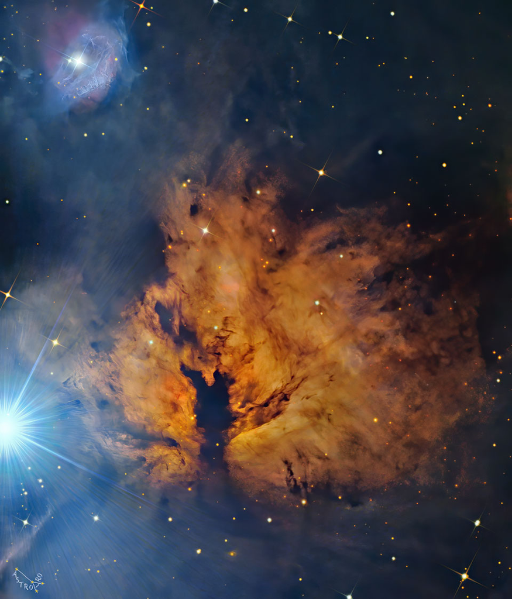

- Researchers often spend time submitting jobs, checking on jobs
- When jobs complete, they decided if they want to submit more jobs
- This is time consumuing, tedious, can be error prone
- Anything repetitive can be *automated*

## What is ‘Workflow Management Software’?

- Workflows are sets of tasks that depend on each other
- Workflow Management Software (WMS)
  - Tracks how jobs relate to each other
  - Tracks output files
  - Submits jobs for you
  - Resubmits if needed
  - Deletes intermediate files (if you don’t need them)

## Example workflow: Music Visualizer

- R.I.P Daft Punk!
- We will make them a fitting tribute
- I want to run a music visualization program
  - Song broken up into pieces
  - Each pieces represented as an image
  - Merge each piece into a movie
  - Do this for **every** song on **every** album

[figure not shown]

## Example workflow: Input data

- For this tutorial, we’ll use music with permissive licensing :)
- [Symphonie fantastiqe - Hector Berlioz](https://en.wikipedia.org/wiki/Symphonie_fantastique)
- Downloadable here https://www.liberliber.it/online/autori/autori-b/hector-berlioz/symphonie-fantastique-op-14-concertgebouw-orchestra-of-amsterdam/
- Cleaned up filenames available here:
  - https://app.globus.org/file-manager?origin_id=5eebdcc6-9760-458a-a963-456d0590f311&origin_path=%2F (download to your project with Globus)
  - `-wget --no-check-certificate https://g-3d96ec.a78b8.36fe.data.globus.org/symphonie_fantastique.tar` (download tar file)
- Once you have `symphonie_fantastique.tar`, you can extract with `tar xfv symphonie_fantastique.tar`
  - Ideally put it in `data` directory

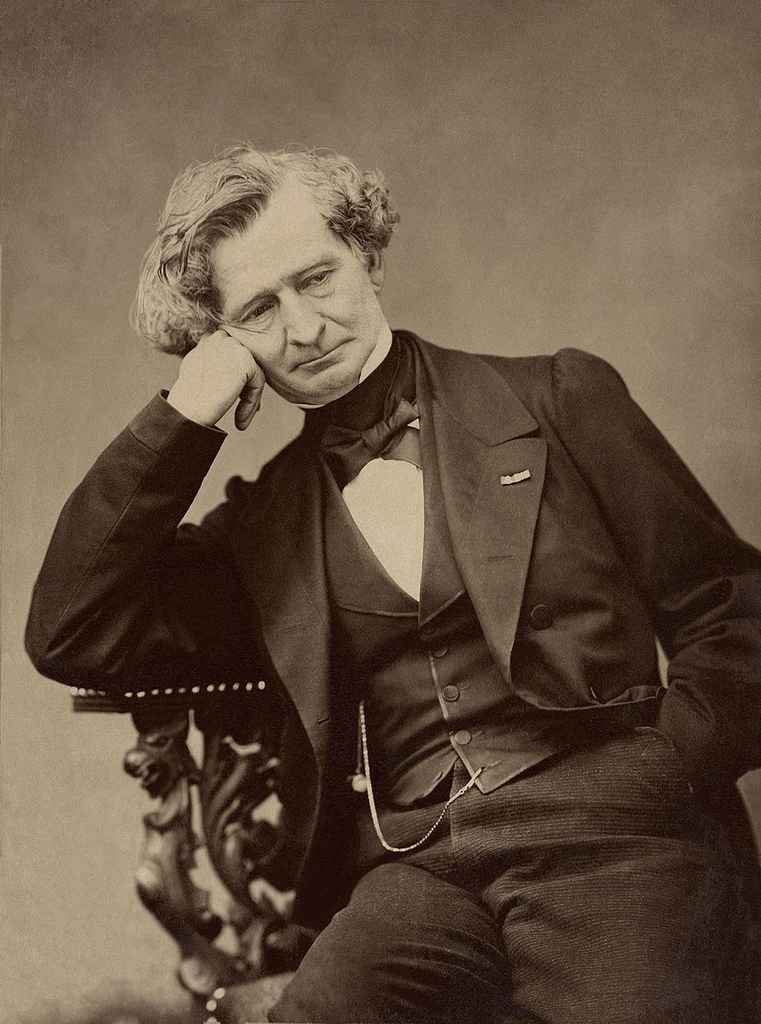

## Example workflow: Music Visualizer

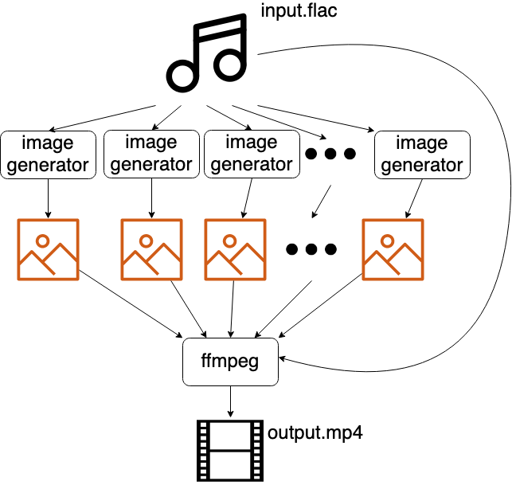

- There are 2 kinds of jobs
- “image generator”
  - Takes `input.flac` song file as input
  - Song is divided in into timed segments
  - Each segment is represted as series of images
  - 1 picture for every 1/60th of a second
  - Can run in any order
- `ffmpeg`
  - Merges all image files and `input.flac`
  - creates `output.mp4`
  - Can not run until **all** images are created

## Example workflow: Music Visualizer

- When complete, output files should be available under `output`

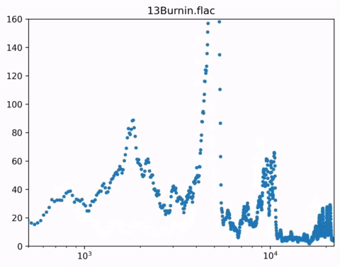

- We should find
  - `output/<song_name>/<song_name>.mp4`
  - `output/<song_name>/images/*.png`

## Job type:`rosa_fft.py`

- “image generator” is a python script, `rosa_fft.py`
  - `python3 rosa_fft.py -f 09Teachers.flac -i 172 -d 4 -o 09Teachers`

[output not shown]

## Job type:`ffmpeg`

- ffmpeg is used to create movie file
  - `ffmpeg -threads 8 -framerate 60 -i 16Funk_Ad/images/frame%d.png -i 16Funk_Ad.flac -pix_fmt yuv420p 16Funk_Ad.mp4`

| option | meaning |
| --- | --- |
| -threads | How many cpus to use when converting fiels |
| -framerate | How many pictures per second |
| -i | name or name pattern for input file(s) |
| -pix_fmt yuv420p | video encoding option? |
| output_file.mp4 | output file name |

## Job Arrays

- Built-in Slurm feature https://slurm.schedmd.com/job_array.html
- Use same job script for multiple jobs
- Process first 40 seconds of song

rosa_fft_array.slurm:

```bash
#!/bin/bash
#SBATCH --ntasks=1
#SBATCH --mem-per-cpu-1GB
#SBATCH --time=00:10:00
#SBATCH --array=0-9
module load python ffmpeg

# How many seconds to process per job
duration=4
time_index=$((SLURM_ARRAY_TASK_ID*duration))
song_file="data/symphonie_fantastique/berlioz_symphonie_2_un_bal_vals.mp3"
out_dir="output/berlioz_symphonie_2_un_bal_vals"

echo "Processing time_index:${time_index}"

python3 ./scripts/rosa_fft.py -f ${song_file} \
-i ${time_index} -t ${duration} -o ${out_dir}
```

- `$SLURM_ARRAY_TASK_ID` will be any number from 0-9

## Job Arrays

- Job script can be found in `examples/job_array`
- The important part is

```bash
python3 ./scripts/rosa_fft.py -f ${song_file} \
-i ${time_index} -t ${duration} -o ${out_dir}
```

| Variable | meaning | value |
| --- | --- | --- |
| `${song_file}` | Song file to process | `data/symphonie_fantastique/berlioz_symphonie_2_un_bal_vals.mp3` |
| `$SLURM_ARRAY_TASK_ID` | Which array element are we? | 0-9 |
| `${duration}` | How many seconds to process? | 4 |
| `${time_index}` | Time to start processing | `$((SLURM_ARRAY_TASK_ID*duration))` |
| `${out_dir}` | Where to save output data | `output/berlioz_symphonie_2_un_bal_vals` |

## Job Arrays

- Merge results with second job script
- `examples/job_array/ffmpeg.slurm`

ffmpeg.slurm:

```bash
#!/bin/bash
#SBATCH --cpus-per-task=4
#SBATCH --mem-per-cpu=1GB
#SBATCH --time=00:10:00
module load ffmpeg

song_file="data/symphonie_fantastique/berlioz_symphonie_2_un_bal_vals.mp3"
frame_dir="output/berlioz_symphonie_2_un_bal_vals/images"
out_file="output/berlioz_symphonie_2_un_bal_vals.mp4"

ffmpeg \
-framerate 60 -i ${frame_dir}/frame%d.png \
-i ${song_file} \
-pix_fmt yuv420p \
-threads ${SLURM_CPUS_PER_TASK} \
${out_file}
```

## Job dependencies

- This job cannot run until every element of `rosa_fft_array.slurm` completes.
- Instead of waiting, we can set a **job dependency**
- We set jobs to wait until others complete before running
- Using `bash` we can capture the job id
  - When submitting job, Slurm returns `Submitted batch job XXXXX`
  - We can use `cut` to parse text

`examples/job_array/manager.sh`:

```bash
#!/bin/bash

# save 4th word using ' ' as delmiter
# AKA the job id
jid=$(sbatch examples/job_array/job_array.slurm | cut -d ' ' -f 4)

sbatch --dependency=afterok:${jid} examples/job_array/ffmpeg.slurm
```

## Job array remarks

- Some basic features of a workflow manager
  - Some tasks are independent
  - Some have dependencies
  - “Template” tasks
- Easy to get set up for simple cases
- Can get out of hand quickly
- No method to handle errors
  - What if only some tasks fail?
- Large arrays can put load on scheduler

## Workflow managers

- WMS have syntax to describe the workflow
- Usually task
  - input
  - output
  - command to generate output file
- Optional:
  - Rules if task fails
  - Compute resources for task
  - How many tasks to run in parallel
- Task order is tracked by input/output files

## SnakeMake

- A future version of this presentation will have more info on [SnakeMake](https://snakemake.readthedocs.io/en/stable/tutorial/short.html)
- Python based
- Includes features for tracking software dependencies
- Prioritizes readability
- Syntax is kind of obtuse

```bash
rule bwa:
    input:
        "data/genome.fa",
        "data/samples/{sample}.fastq"
    output:
        temp("mapped/{sample}.bam")
    conda:
        "envs/mapping.yaml"
    threads: 8
    shell:
        "bwa mem -t {threads} {input} | samtools view -Sb - > {output}"
```

## Parts of pegasus workflow

- Pegasus is developed at USC
- Manages **LARGE** workflows
- workflow generator
- catalogs
  - transformation.yml
    - Where are executables?
  - sites.yml
    - Details on execution site
  - replicas.yml
    - Where are files saved?
- workflow.yml
  - List of every job
  - input files
  - output files
  - executable
  - arguments
  - dependent jobs

## Makeflow

- We will use [Makeflow](http://ccl.cse.nd.edu/software/makeflow/) as an example
- The choice is kind of arbitrary
  - In general choose something that you are comfortable with
  - Something that has large userbase incase you need support

## Makeflow file

- Makeflow can be used similar to `MakeFile` used in building software
- Format is:

```bash
outputfile(s): inputfile(s)
# Leading whitespace below must be tab character, not spaces!
        command to generate outputfile(s)
```

## Makeflow file

- From the Makeflow Tutorial

```bash
CURL=/usr/bin/curl
CONVERT=/usr/bin/convert
URL="http://ccl.cse.nd.edu/images/capitol.jpg"

capitol.anim.gif: capitol.jpg capitol.90.jpg capitol.180.jpg capitol.270.jpg capitol.360.jpg
    LOCAL $(CONVERT) -delay 10 -loop 0 capitol.jpg capitol.90.jpg capitol.180.jpg capitol.270.jpg capitol.360.jpg capitol.270.jpg capitol.180.jpg capitol.90.jpg capitol.anim.gif

capitol.90.jpg: capitol.jpg
    $(CONVERT) -swirl 90 capitol.jpg capitol.90.jpg

capitol.180.jpg: capitol.jpg
    $(CONVERT) -swirl 180 capitol.jpg capitol.180.jpg

capitol.270.jpg: capitol.jpg
    $(CONVERT) -swirl 270 capitol.jpg capitol.270.jpg

capitol.360.jpg: capitol.jpg
    $(CONVERT) -swirl 360 capitol.jpg capitol.360.jpg

capitol.jpg:
    LOCAL $(CURL) -o capitol.jpg $(URL)
```

## Makeflow file

- Here’s a snippet of a Makeflow file:

```bash
./berlioz_symphonie_1_reveries_pa/berlioz_symphonie_1_reveries_pa.mp4: ./berlioz_symphonie_1_reveries_pa/images/frame000000000.png ./berlioz_symphonie_1_reveries_pa/images/frame000000001.png ./berlioz_symphonie_1_reveries_pa/images/frame000000002.png ./berlioz_symphonie_1_reveries_pa/images/frame000000003.png ./berlioz_symphonie_1_reveries_pa/images/frame000000004.png ./berlioz_symphonie_1_reveries_pa/images/frame000000005.png ./berlioz_symphonie_1_reveries_pa/images/frame000000006.png ./berlioz_symphonie_1_reveries_pa/images/frame000000007.png ./berlioz_symphonie_1_reveries_pa/images/frame000000008.png ./berlioz_symphonie_1_reveries_pa/images/frame000000009.png ./berlioz_symphonie_1_reveries_pa/images/frame000000010.png ./berlioz_symphonie_1_reveries_pa/images/frame000000011.png ./berlioz_symphonie_1_reveries_pa/images/frame000000012.png ./berlioz_symphonie_1_reveries_pa/images/frame000000013.png ./berlioz_symphonie_1_reveries_pa/images/frame000000014.png ./berlioz_symphonie_1_reveries_pa/images/frame000000015.png
    fmpeg -threads 4 -framerate 60 -i Homework/04Da_Funk/images/frame%09d.png -i data/Homework/04Da_Funk.flac -pix_fmt yuv420p  Homework/04Da_Funk/04Da_Funk.mp4

./berlioz_symphonie_1_reveries_pa/images/frame000000000.png ./berlioz_symphonie_1_reveries_pa/images/frame000000001.png ./berlioz_symphonie_1_reveries_pa/images/frame000000002.png ./berlioz_symphonie_1_reveries_pa/images/frame000000003.png ./berlioz_symphonie_1_reveries_pa/images/frame000000004.png ./berlioz_symphonie_1_reveries_pa/images/frame000000005.png ./berlioz_symphonie_1_reveries_pa/images/frame000000006.png ./berlioz_symphonie_1_reveries_pa/images/frame000000007.png ./berlioz_symphonie_1_reveries_pa/images/frame000000008.png ./berlioz_symphonie_1_reveries_pa/images/frame000000009.png ./berlioz_symphonie_1_reveries_pa/images/frame000000010.png ./berlioz_symphonie_1_reveries_pa/images/frame000000011.png ./berlioz_symphonie_1_reveries_pa/images/frame000000012.png ./berlioz_symphonie_1_reveries_pa/images/frame000000013.png
    python3 /scripts/rosa_fft.py -f /project/hpcroot/csul/workshop-workflows/data/symphonie_fantastique/berlioz_symphonie_1_reveries_pa.mp3  -i 1 -o ./berlioz_symphonie_1_reveries_pa
```

- A few remarks
  - For more than a few files, Makeflow file is hard to read
  - Can be tedious to write by hand

## Makeflow JX

- Makeflow also supports **J**SON e**X**tended syntax

```
"rules":[
         {
            "outputs":["input.txt"],
            "command":"echo \"Hello Makeflow!\" > input.txt",
            "local_job":true,
         },
         {
            "outputs":[format("output.%d",i)],
            "inputs":["simulation.py","input.txt"],
            "command":format("./simulation.py %d < input.txt > output.%d", i, i),
         } for i in range(1,5)
        ],
}
```

## Makeflow JX

```
    "define":
            {
                "OUTDIR":"output/berlioz_symphonie_2_un_bal_vals/images",
                "SONGNAME" : "berlioz_symphonie_2_un_bal_vals",
                "FFMPEG_THREADS" : 4,
                "FRAME_RATE" : 60,
                "SONG_DURATION": 370
            },
    "rules":[
                # Merge all frames into 1 video
                {
                    "command" : format("ffmpeg -threads %d -framerate %d -i output/%s/images/frame\%%d.png  -i ../../data/symphonie_fantastique/%s.mp3 output/%s/%s.mp4",FFMPEG_THREADS,FRAME_RATE,SONGNAME,SONGNAME,SONGNAME,SONGNAME),
                    "inputs"  : [ format("output/%s/images/frame%d.png",SONGNAME, x) for x in range(0,SONG_DURATION*FRAME_RATE)],
                    "output"  : [format("output/%s/%s.mp4",SONGNAME,SONGNAME)],
                },{
                    "command" : format("python3 ../../scripts/rosa_fft.py -f ../../data/symphonie_fantastique/%s.mp3 -i "+N+" -o output/%s",SONGNAME,SONGNAME),
                    "inputs"  : ["../../scripts/rosa_fft.py" , format("../../data/symphonie_fantastique/%s.mp3",SONGNAME)],
                    "outputs":
                      [
                        format("%s/frame%d.png",OUTDIR,x) for x in range(N*FRAME_RATE,(N+1)*FRAME_RATE)
                      ]
                } for N in range(0,370)
            ]
}
```

## Makeflow JX to JSON

```
  "define":
    {
      "OUTDIR":"output/berlioz_symphonie_2_un_bal_vals/images",
      "SONGNAME":"berlioz_symphonie_2_un_bal_vals",
      "FFMPEG_THREADS":4,
      "FRAME_RATE":60,
      "SONG_DURATION":370
    },
  "rules":
    [

      {
        "command":"ffmpeg -threads 4 -framerate 60 -i output/berlioz_symphonie_2_un_bal_vals/images/frame%d.png  -i ../../data/symphonie_fantastique/berlioz_symphonie_2_un_bal_vals.mp3 output/berlioz_symphonie_2_un_bal_vals/berlioz_symphonie_2_un_bal_vals.mp4",
        "inputs":
          [
            "output/berlioz_symphonie_2_un_bal_vals/images/frame0.png",
            "output/berlioz_symphonie_2_un_bal_vals/images/frame1.png",
            .
            .
            .
            "output/berlioz_symphonie_2_un_bal_vals/images/frame22199.png"
        ],
        "output":
        "output/berlioz_symphonie_2_un_bal_vals/berlioz_symphonie_2_un_bal_vals.mp4"
        }
```

## Running a Makeflow

- Assume we have a Makeflow file that converts a song
- How do we use it?
- For small number of jobs we can run locally
- You’ll have to put your own songs under data
- Let’s run in interactive session
- `salloc --ntasks=1 --cpus-per-task=8 --time=1:00:00 --mem-per-cpu=2GB`
- Example file in `examples/clip/berlioz_symphonie_2_un_bal_vals.jx`

## Running a Makeflow

- Run the makeflow

```bash
$ makeflow --jx clip_berlioz_symphonie_2_un_bal_vals.jx
parsing clip_berlioz_symphonie_2_un_bal_vals.jx...
local resources: 32 cores, 191863 MB memory, 1438549300 MB disk
max running local jobs: 32
checking clip_berlioz_symphonie_2_un_bal_vals.jx for consistency...
clip_berlioz_symphonie_2_un_bal_vals.jx has 4 rules.
creating new log file clip_berlioz_symphonie_2_un_bal_vals.jx.makeflowlog...
checking files for unexpected changes...  (use --skip-file-check to skip this step)
starting workflow....
submitting job: python3 ../../scripts/rosa_fft.py -f ../../data/symphonie_fantastique/berlioz_symphonie_2_un_bal_vals.mp3 -i 111 -o output/berlioz_symphonie_2_un_bal_vals
submitted job 211569
submitting job: python3 ../../scripts/rosa_fft.py -f ../../data/symphonie_fantastique/berlioz_symphonie_2_un_bal_vals.mp3 -i 110 -o output/berlioz_symphonie_2_un_bal_vals
submitted job 211570
submitting job: python3 ../../scripts/rosa_fft.py -f ../../data/symphonie_fantastique/berlioz_symphonie_2_un_bal_vals.mp3 -i 109 -o output/berlioz_symphonie_2_un_bal_vals
submitted job 211571

job 211569 completed
job 211570 completed
job 211571 completed
submitting job: ffmpeg -threads 4 -framerate 60 -start_number 6540 -i output/berlioz_symphonie_2_un_bal_vals/images/frame%d.png -ss 00:01:49 -to 00:01:52 -i ../../data/symphonie_fantastique/berlioz_symphonie_2_un_bal_vals.mp3 output/berlioz_symphonie_2_un_bal_vals/berlioz_symphonie_2_un_bal_vals.mp4
submitted job 216156

job 216156 completed
deleted makeflow.failed.0
nothing left to do.
```

## Running a Makeflow

- Output files should be available under `examples/clips/output`

[figure not shown]

- We should find
  - `/<song_name>/<song_name>.mp4`
  - `/<song_name>/images/*.png`

## Cleaning up

- The `images` directory contains intermediate files
- Not needed after final product is complete
- Clean with `makeflow --clean=intermediates examples/clip/01Daftendirekt.jx`

```r
$ makeflow --clean=intermediates --jx  clip_berlioz_symphonie_2_un_bal_vals.jx
parsing clip_berlioz_symphonie_2_un_bal_vals.jx...
local resources: 32 cores, 191863 MB memory, 1438503624 MB disk
max running local jobs: 32
checking clip_berlioz_symphonie_2_un_bal_vals.jx for consistency...
clip_berlioz_symphonie_2_un_bal_vals.jx has 4 rules.
recovering from log file clip_berlioz_symphonie_2_un_bal_vals.jx.makeflowlog...
checking for old running or failed jobs...
checking files for unexpected changes...  (use --skip-file-check to skip this step)
cleaning filesystem...
deleted output/berlioz_symphonie_2_un_bal_vals/images/frame6616.png
deleted output/berlioz_symphonie_2_un_bal_vals/images/frame6578.png
deleted output/berlioz_symphonie_2_un_bal_vals/images/frame6646.png
deleted output/berlioz_symphonie_2_un_bal_vals/images/frame6559.png
```

## Questions?

## Labs/Projects

- Create a set of job arrays that will process first 10s of each song
- Makeflow
  - Write a python script that will generate a makeflow to process an entire song
  - Given a makeflow file with many tasks, try to run on multiple nodes

## Project 1 Job array

- Create a set of job arrays that will process first 10s of each song
- Comes with `projects/project1/job_array.slurm_template`

```bash
#!/bin/bash
#SBATCH --ntasks=1
#SBATCH --mem-per-cpu-1GB
#SBATCH --time=00:10:00
#SBATCH --array=0-9
module load python ffmpeg libsndfile

# How many seconds to process per job
duration=4
time_index=$((SLURM_ARRAY_TASK_ID*duration))
song_file="XXX.mp3"
out_dir="output/XXX"

echo "Processing time_index:${time_index}"

python3 ./scripts/rosa_fft.py -f ${song_file} -i ${time_index} -t ${duration} -o ${out_dir}
```

- Hint: `sed 's/XXX/cool_song/g' job_array.slurm_template` will find every `XXX` and replace with `cool_song`
- Use files in `examples/job_array` as needed

## Project 2 Generate a Makeflow

- Write a python script that will generate a makeflow to process all songs in a directory
- Project was based on an earlier version of this presentation, start point not working right now :(
- You can find a script to get started in `projects/project2/generate_makefile.py`
- Run it to get an idea of the format
- It contains 3 “jobs”
- They don’t do anything but it does demonstrate the format
- My solution (no peeking!) is there was there but got overwritten on accident :(
  - I’ve been using it to generate makeflow files for this presentation

## Project 3 Run a large Makeflow

- What if we have many tasks we want to run?
  - Considering most songs are at least a few minutes long (100s of ‘jobs’)
- We can spread the work out over multiple compute nodes
- We need to run 2 kinds of processes
- Daemon (background process)
  - Reads the Makeflow file assigns work
- Worker process
  - Looks for Daemon and requests work

## Projec 3 Running a large Makeflow

```
parsing makeflows/Blitz_it.makeflow...
local resources: 20 cores, 64334 MB memory, 5566556492 MB disk
max running remote jobs: 1000
max running local jobs: 20
checking makeflows/Blitz_it.makeflow for consistency...
makeflows/Blitz_it.makeflow has 72 rules.
submitted job 43
submitting job: python3 ./scripts/rosa_fft.py -f data/chirpy/Blitz_it.wav -i 27 -o ./Blitz_it
submitted job 44
submitting job: python3 ./scripts/rosa_fft.py -f data/chirpy/Blitz_it.wav -i 26 -o ./Blitz_it
submitted job 45
submitting job: python3 ./scripts/rosa_fft.py -f data/chirpy/Blitz_it.wav -i 25 -o ./Blitz_it
submitted job 46
submitting job: python3 ./scripts/rosa_fft.py -f data/chirpy/Blitz_it.wav -i 24 -o ./Blitz_it
submitted job 47
submitting job: python3 ./scripts/rosa_fft.py -f data/chirpy/Blitz_it.wav -i 23 -o ./Blitz_it
submitted job 48
submitting job: python3 ./scripts/rosa_fft.py -f data/chirpy/Blitz_it.wav -i 22 -o ./Blitz_it
submitted job 49
submitting job: python3 ./scripts/rosa_fft.py -f data/chirpy/Blitz_it.wav -i 21 -o ./Blitz_it
submitted job 50
submitting job: python3 ./scripts/rosa_fft.py -f data/chirpy/Blitz_it.wav -i 20 -o ./Blitz_it
```

## Running a large Makeflow

  ```
  work_queue_worker: creating workspace /scratch/csul/makeflow/example/worker-268648-412
  work_queue_worker: creating workspace /scratch/csul/makeflow/example/worker-268648-416
  work_queue_worker: creating workspace /scratch/csul/makeflow/example/worker-268648-406
  work_queue_worker: creating workspace /scratch/csul/makeflow/example/worker-268648-404
  work_queue_worker: using 24 cores, 193123 MB memory, 185757288 MB disk, 0 gpus
  connected to manager d06-15.hpc.usc.edu:8080 via local address 10.125.19.236:57664
  work_queue_worker: using 24 cores, 193123 MB memory, 185757288 MB disk, 0 gpus
  connected to manager d06-15.hpc.usc.edu:8080 via local address 10.125.19.236:57668
  work_queue_worker: using 24 cores, 193123 MB memory, 185757288 MB disk, 0 gpus
  connected to manager d06-15.hpc.usc.edu:8080 via local address 10.125.19.236:57672
  work_queue_worker: using 24 cores, 193123 MB memory, 185757284 MB disk, 0 gpus
  connected to manager d06-15.hpc.usc.edu:8080 via local address 10.125.19.234:59316
  ```